# week7

## Question 10.1

Using the same crime data set uscrime.txt as in Questions 8.2 and 9.1, find the best model you can using (a) a regression tree model, and (b) a random forest model. In R, you can use the tree package or the rpart package, and the randomForest package. For each model, describe one or two qualitative takeaways you get from analyzing the results (i.e., don’t just stop when you have a good model, but interpret it too).

### Regression tree model

Read and split data into training and test

```r
crime_data=read.table("http://www.statsci.org/data/general/uscrime.txt", header = TRUE)

set.seed(290)
ind<-sample(2,nrow(crime_data), replace=TRUE, prob=c(0.8,0.2))
training<- crime_data[ind==1,]
testing<- crime_data[ind==2,]
```

Use rpart to train a CART model

```r
library(rpart)
library(rpart.plot)
#Lets take the regression model we used in week5 for comparison
lm.final<-lm(Crime ~ M+Ed+Ineq+Prob+Po1+U2, data=crime_data)
summary(lm.final)
```

```
##
## Call:
## lm(formula = Crime ~ M + Ed + Ineq + Prob + Po1 + U2, data = crime_data)
##
## Residuals:
##     Min      1Q  Median      3Q     Max
## -470.68  -78.41  -19.68  133.12  556.23
##
## Coefficients:
##             Estimate Std. Error t value Pr(>|t|)
## (Intercept) -5040.50     899.84  -5.602 1.72e-06 ***
## M             105.02      33.30   3.154  0.00305 **
## Ed            196.47      44.75   4.390 8.07e-05 ***
## Ineq           67.65      13.94   4.855 1.88e-05 ***
## Prob        -3801.84    1528.10  -2.488  0.01711 *
## Po1           115.02      13.75   8.363 2.56e-10 ***
## U2             89.37      40.91   2.185  0.03483 *
## ---
## Signif. codes:  0 '***' 0.001 '**' 0.01 '*' 0.05 '.' 0.1 ' ' 1
##
## Residual standard error: 200.7 on 40 degrees of freedom
## Multiple R-squared:  0.7659, Adjusted R-squared:  0.7307
## F-statistic: 21.81 on 6 and 40 DF,  p-value: 3.418e-11
```

```r
#Lets now build a regression tree for the same
cr.tree <- rpart(Crime ~ M+Ed+Ineq+Prob+Po1+U2, data=training)

cr.tree
```

```
## n= 36
##
## node), split, n, deviance, yval
##       * denotes terminal node
##
## 1) root 36 5622302.0  873.6389
##   2) Po1< 7.65 20  560078.6  645.3500
##     4) M< 14.55 12  245978.9  568.5833 *
##     5) M>=14.55 8  137306.0  760.5000 *
##   3) Po1>=7.65 16 2717012.0 1159.0000 *
```

```r
summary(cr.tree)
```

```
## Call:
## rpart(formula = Crime ~ M + Ed + Ineq + Prob + Po1 + U2, data = training)
##   n= 36
##
##           CP nsplit rel error    xerror      xstd
## 1 0.41712658      0 1.0000000 1.0480602 0.3329460
## 2 0.03144506      1 0.5828734 0.6685265 0.1962733
## 3 0.01000000      2 0.5514284 0.6685265 0.1962733
##
## Variable importance
##  Po1    M Prob Ineq   Ed   U2
##   34   17   17   14   10    9
##
## Node number 1: 36 observations,    complexity param=0.4171266
##   mean=873.6389, MSE=156175.1
##   left son=2 (20 obs) right son=3 (16 obs)
##   Primary splits:
##       Po1  < 7.65      to the left,  improve=0.41712660, (0 missing)
##       Prob < 0.0418485 to the right, improve=0.27271530, (0 missing)
##       Ed   < 11.65     to the left,  improve=0.12297550, (0 missing)
##       M    < 13.75     to the right, improve=0.10150830, (0 missing)
##       U2   < 2.75      to the left,  improve=0.09731624, (0 missing)
##   Surrogate splits:
##       Prob < 0.0418485 to the right, agree=0.778, adj=0.500, (0 split)
##       M    < 13.3      to the right, agree=0.750, adj=0.437, (0 split)
##       Ineq < 16.9      to the right, agree=0.722, adj=0.375, (0 split)
##       Ed   < 9.45      to the left,  agree=0.667, adj=0.250, (0 split)
##       U2   < 2.75      to the left,  agree=0.667, adj=0.250, (0 split)
##
## Node number 2: 20 observations,    complexity param=0.03144506
##   mean=645.35, MSE=28003.93
##   left son=4 (12 obs) right son=5 (8 obs)
##   Primary splits:
##       M    < 14.55     to the left,  improve=0.31565860, (0 missing)
##       Ed   < 10.85     to the right, improve=0.07761792, (0 missing)
##       Prob < 0.055552  to the right, improve=0.07211944, (0 missing)
##       Ineq < 21.5      to the left,  improve=0.06633713, (0 missing)
##       U2   < 3.35      to the right, improve=0.05945596, (0 missing)
##   Surrogate splits:
##       Ineq < 21.5      to the left,  agree=0.85, adj=0.625, (0 split)
##       Ed   < 9.2       to the right, agree=0.80, adj=0.500, (0 split)
##       Po1  < 6.15      to the right, agree=0.70, adj=0.250, (0 split)
##       Prob < 0.0840015 to the left,  agree=0.65, adj=0.125, (0 split)
##       U2   < 4.05      to the left,  agree=0.65, adj=0.125, (0 split)
##
## Node number 3: 16 observations
##   mean=1159, MSE=169813.2
##
## Node number 4: 12 observations
##   mean=568.5833, MSE=20498.24
##
## Node number 5: 8 observations
##   mean=760.5, MSE=17163.25
```

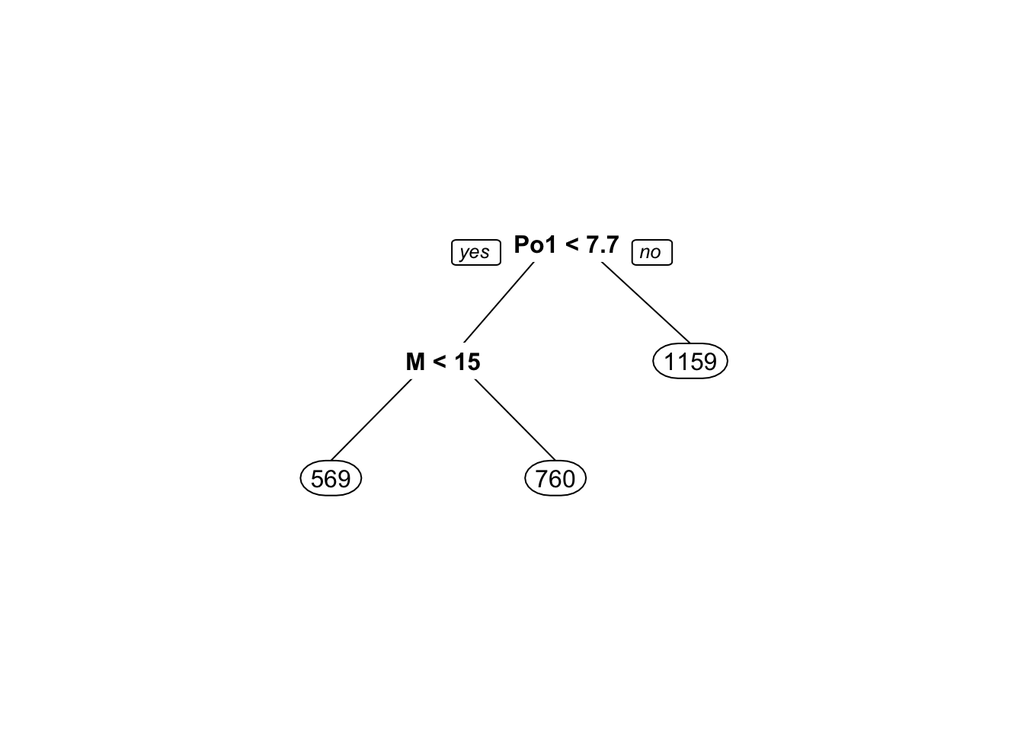

```r
prp(cr.tree)
```

```r
#RMSE
cr.tree.pred<-predict(cr.tree,testing[,-16])
res.compare.tree<-cbind.data.frame(t(t(cr.tree.pred)),testing[,16])
colnames(res.compare.tree)<-c("Pred","Actual")
res.compare.tree
```

```
##         Pred Actual
## 2  1159.0000   1635
## 5  1159.0000   1234
## 9   760.5000    856
## 20 1159.0000   1225
## 29 1159.0000   1043
## 32 1159.0000    754
## 33  760.5000   1072
## 34 1159.0000    923
## 36 1159.0000   1272
## 38  568.5833    566
## 46 1159.0000    508
```

```r
library(ModelMetrics)
rmse(res.compare.tree$Actual,res.compare.tree$Pred)
```

```
## [1] 303.3844
```